# Deep Learning + Tensorflow

*CHS Data Analytics*  
Eric Czech

# What is Deep Learning?

# History of Deep Learning

- 1943: McCulloch and Pitts credited with first ANN model
- 1957: Vladimir Arnold showed that single-layer NN can be used to solve Hilbert's 13th problem
- 1958: Frank Rosenblatt created the (much overly hyped) Perceptron algorithm
- 1962: Backpropogation algorithms derived
- 1969: Minsky and Papert showed that Perceptron could not solve XOR problem
- 1971: First reasonable results from many-layer networks published

... **corporate and government research stops caring for a while until about mid 80s** ...

- 1989: Universal approximation of NNs shown (Cybenko, Funahashi, Hornik, Stinchcombe, White)
- 1986: First use of the word "Deep Learning" seen in publications
- 1992: Unsupervised pre-training applied to make training deep networks possible
- 1992: "Pooling" layers for ANNs proposed
- 2003: First published use cases for deep, convolutional neural networks in computer vision
- 2004: Fast GPU based implementations of ANNs used

... **deep learning sort of "begins"** ...

- 2005+: CNNs and LSTMs (both deep networks) start crushing old benchmarks
- 2006: Yoshua Bengio, Yann LeCun, and Geoff Hinton begin commercialization of deep networks in North America
  - Sometimes called "Deep Learning Conspiracy"
  - They often cite each other and are just as often given credit as creators of Deep Learning
  - Jürgen Schmidhuber - the forgotten creator
- 2006+: Deep Learning applied by companies to tons of things (Genomics, Speech Recognition, Vision, etc)
- 2012: Hinton's team kills on Kaggle Merck Challenge
- 2015: "Deep Learning" paper published in Nature (Bengio, Hinton, LeCun)
  - Schmidhuber not happy: http://people.idsia.ch/~juergen/deep-learning-conspiracy.html
- Other recent developments to improve deep network training:
  - Batch Normalization
  - Advanced Optimizers (improving upon vanilla gradient descent)
  - Dropout
  - Empirical results favoring recified linear activation functions

# Agenda

- **Theory**
  - Optimization and Gradient Descent
  - Single layer networks can learn anything
  - Multi-Layer networks can learn anything ... but usually with less parameters
  - Asymptotic limits of single vs multi layer networks
    - Depth provides exponential gains
- **Practice**
  - Python / Tensorflow Setup and Installation
  - Tensorflow Mechanics
  - Applications of Tensorflow
  - Why Tensorflow matters for companies without petabyte-sized datasets

# Optimization

### How else can we fit a linear regression problem (rather than OLS)?

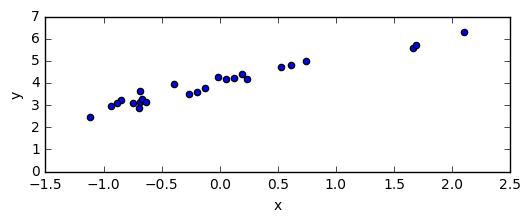

```python
# Generate a random linear regression problem
np.random.seed(1)
n = 25
b0, b1, e = 4, 1, .2 * np.random.randn(n)
x = np.random.randn(n)
y = b0 + b1*x + e

# Plot the single variable (x) and response (y)
plt.figure(figsize=(6,2))
plt.scatter(x, y)
plt.xlabel('x')
plt.ylabel('y')
plt.ylim(0, 7)
print()
```

### Need to minimize RSS

```python
Image(url='https://i.stack.imgur.com/ddJFC.png', width=500)
```

[figure not shown]

```python
Image(url='http://ww2.tnstate.edu/ganter/BIO-311-Ch12-Eq5a.gif', width=500)
```

[figure not shown]

# RSS Surface

```python
Image(url='https://i.stack.imgur.com/bmg5Z.png', width=500)
```

[figure not shown]

### Gradient Descent

```python
from IPython.display import Image
#Image(url='https://www.cs.toronto.edu/~frossard/post/linear_regression/sgd.gif')
Image(url='https://alykhantejani.github.io/images/gradient_descent_line_graph.gif')
```

[figure not shown]

# Single-Layer Neural Networks

# Linear Regression

Linear regression is a type of neural network:

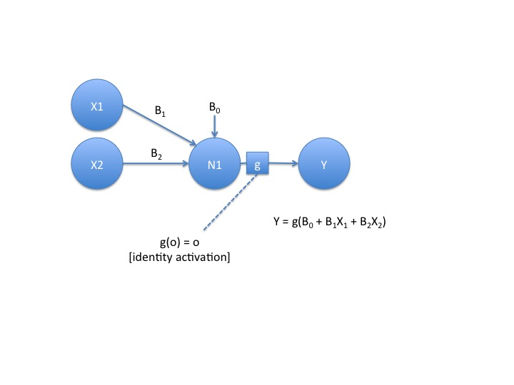

```python
Image('media/network_architectures/Slide2.jpg', width=800)
```

# Decision Function (linear regression)

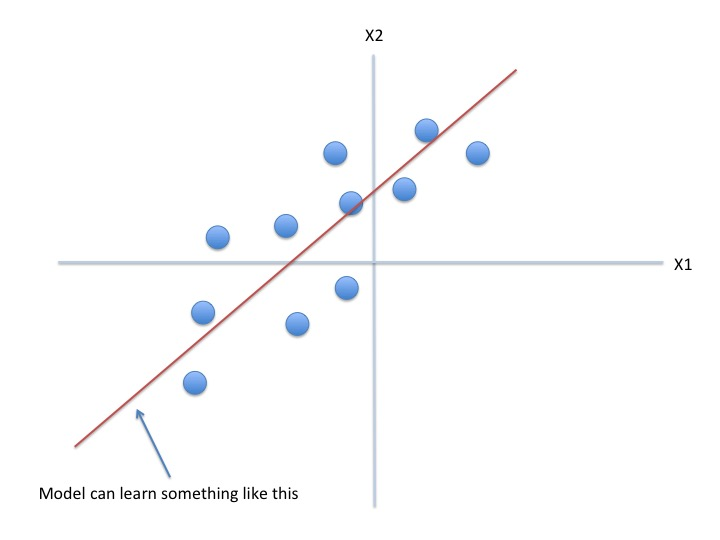

```python
Image('media/network_architectures/Slide3.jpg', width=800)
```

# Logistic Regression

Logistic regression can also be expressed this way, just need to change the activation function:

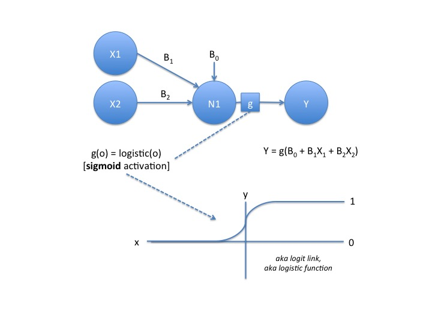

```python
Image('media/network_architectures/Slide4.jpg', width=800)
```

# Decision Function (logistic regression)

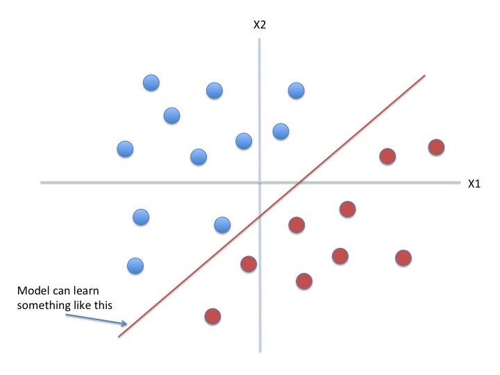

```python
Image('media/network_architectures/Slide5.jpg', width=800)
```

# "Double" Logistic Regression

Adding neurons is like adding extra models of the original form, in this case two logistic regressions:

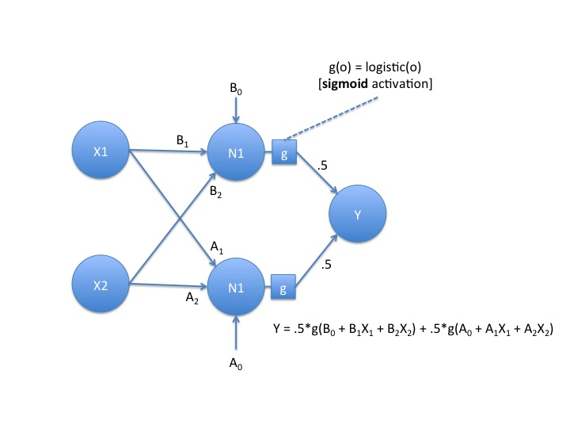

```python
Image('media/network_architectures/Slide6.jpg', width=800)
```

# Decision Function (double logistic regression)

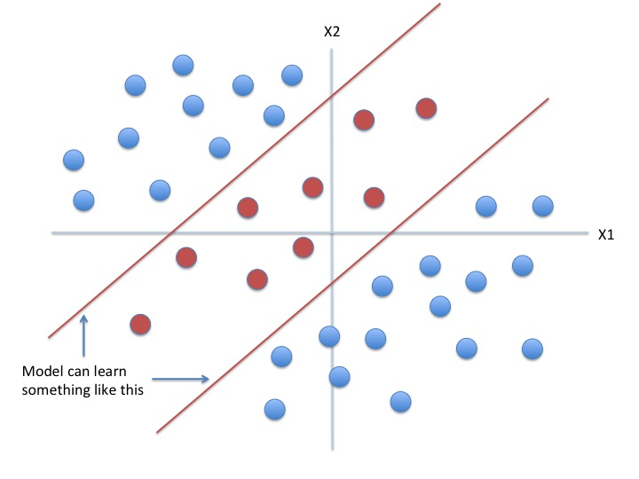

```python
Image('media/network_architectures/Slide7.jpg', width=800)
```

# Activation Functions

# Sigmoid Activation

Parameterization of one single sigmoid neuron can do relatively complex things: [Sigmoid -> Step Function](http://neuralnetworksanddeeplearning.com/movies/step_3d.mp4)

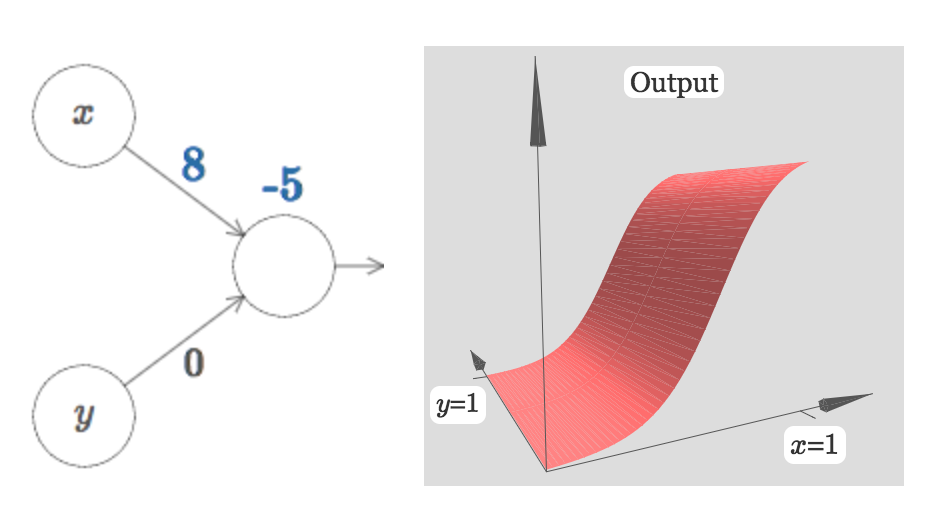

```python
Image('media/nn1.png', width=800)
```

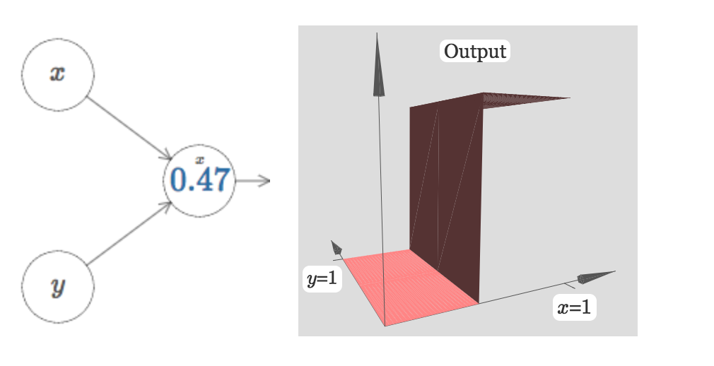

```python
Image('media/nn2.png', width=800)
```

# Adding More Neurons

More neurons means more "folds":

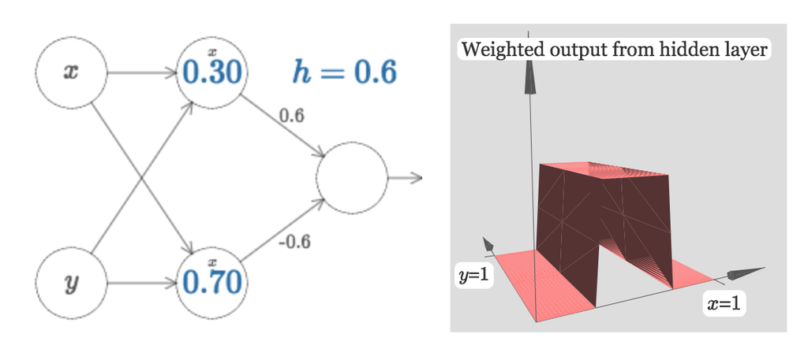

```python
Image('media/nn3.png', width=800)
```

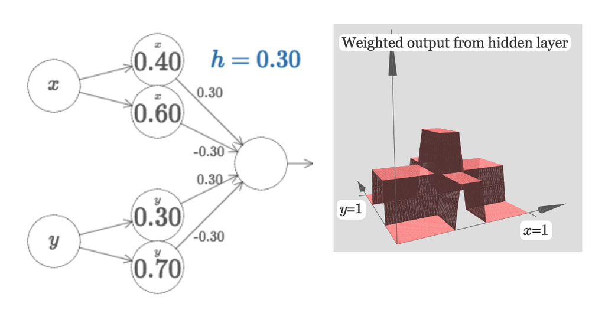

```python
Image('media/nn4.png', width=800)
```

# Arbitrary Function Approximation

This type of reasoning was how ANNs have been shown to approximate any function

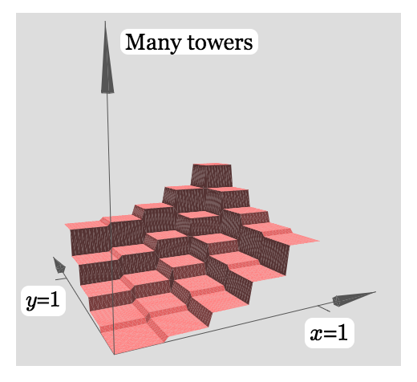

```python
Image('media/nn5.png', width=500)
```

Takeaway: Through many "towers" like this, an ANN can approximate any 3D function with just 2 inputs.